# Waves and Cycles

## Dependent contention

## Scale shift

Scale shift means moving contention to “a higher or a lower level than its initiation”. Achieved through:

- Coordination
- Brokerage
- Claim shifts
- Identity shifts

# The cycle of contention

1. Heightened conflict
2. Geographic and sectoral diffusion
3. Organizational emergence
4. New frames and identities
5. Expansion of the repertoire

[figure not shown]

## 1960s

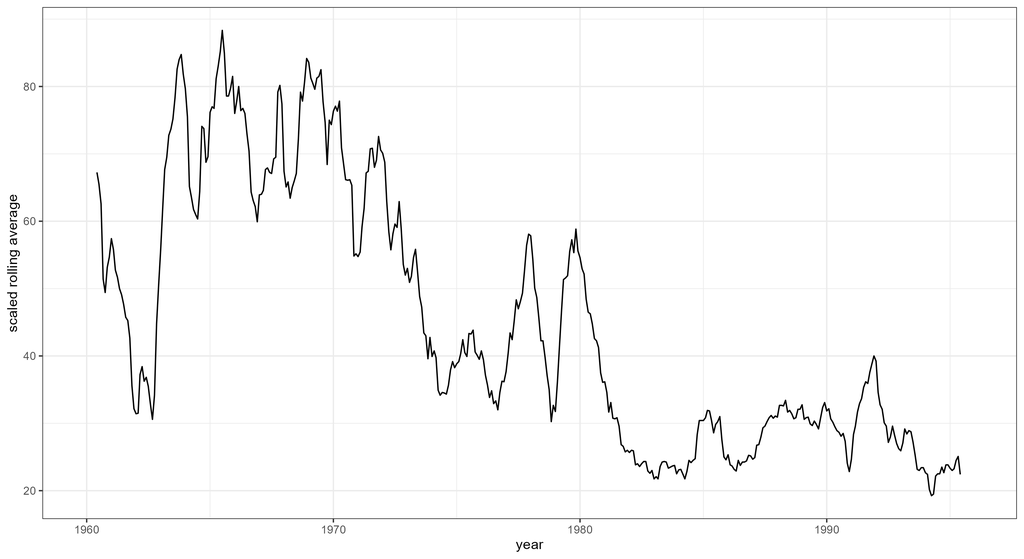

- Widening opportunity, economic boom, postwar instability, youth bulge - among others - lead to heightened racial conflict in the U.S. in the 1950s/1960s

### Sectoral/Geographic Diffusion

- As Civil Rights activism increased, it also moved to new areas - such as the deep south - and invited greater institutional involvement (political parties, charitable organizations, churches, the left, white students etc.)

[figure not shown]

### New groups

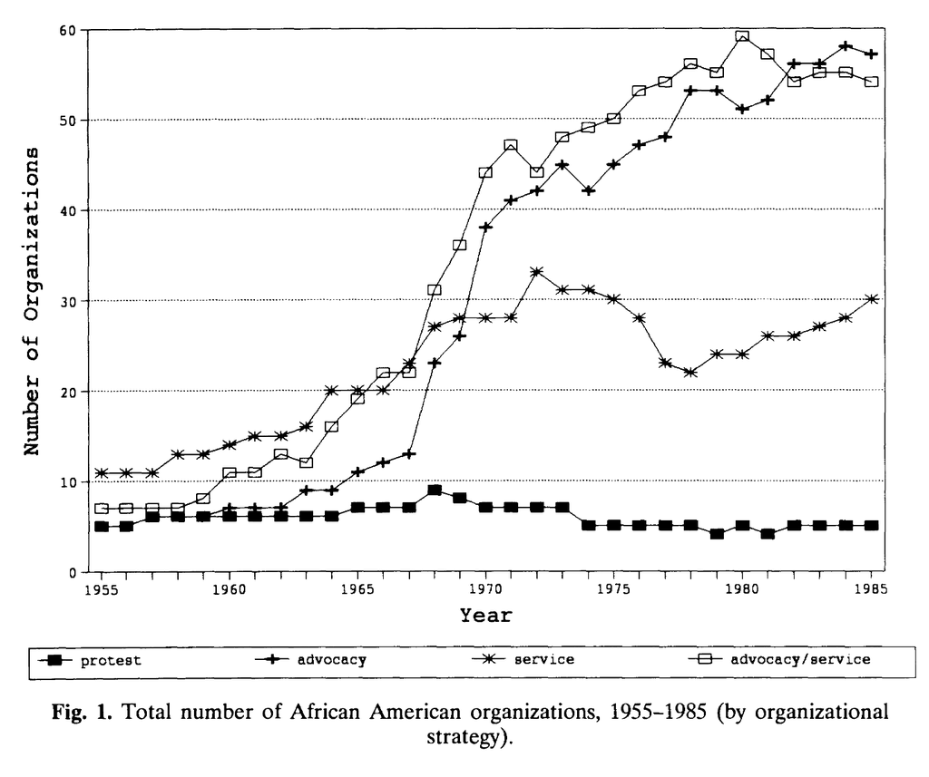

- As the 60s progressed, new organizations/organizational forms arose to take advantage of the increased resources available for civil rights activism.

### Expanded Repertoire

- Tactical innovations (particularly sit-ins, boycotts, marches and other direct actions) proliferated and became normalized by the 1970s and later more militant activism took their place

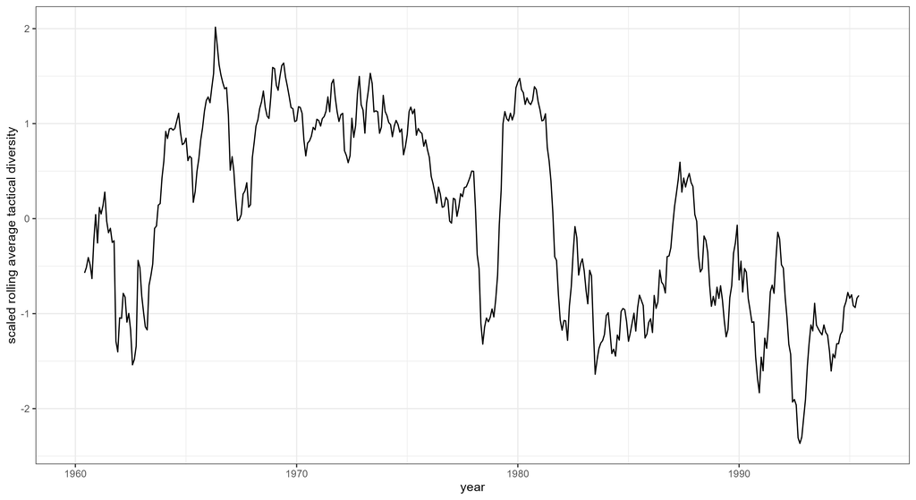

### New claims and identities

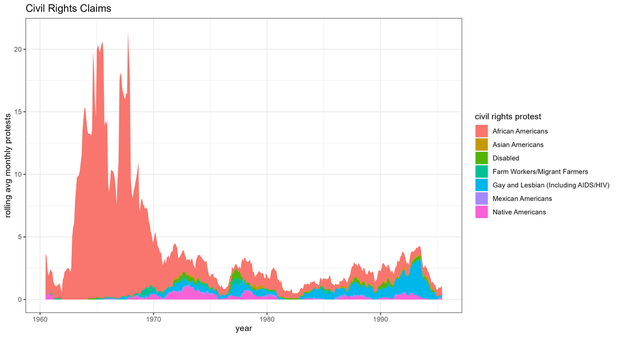

- New Civil Rights movements - often deliberately modeled on AA Civil Rights - became more prominent in later decades.

## Color Revolutions

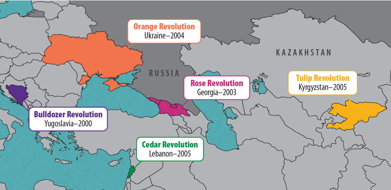

## Revolutions of 1848

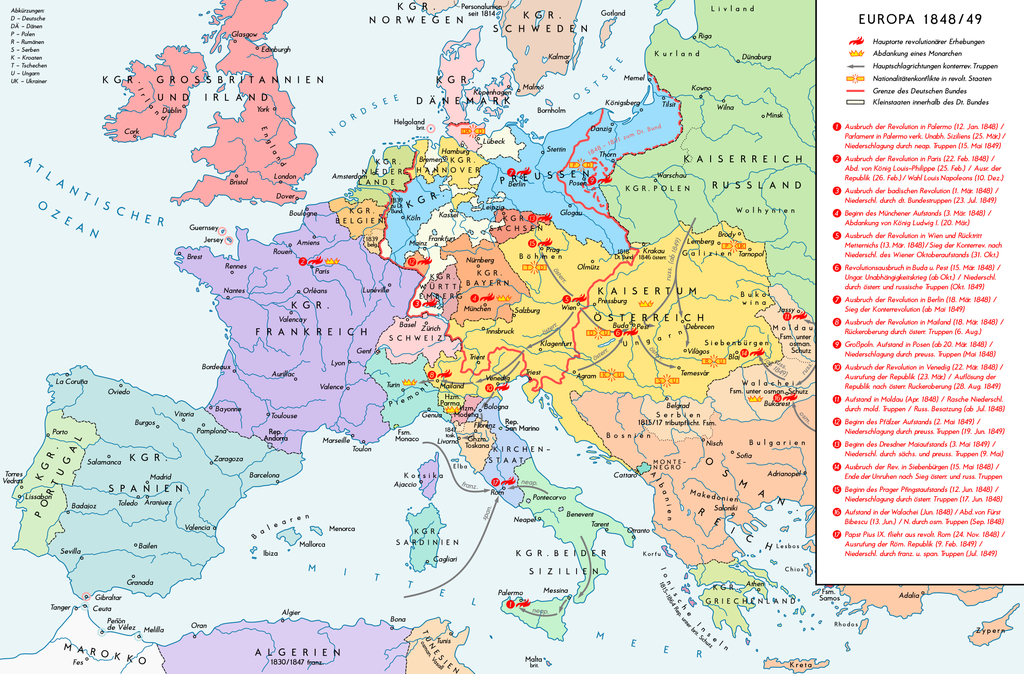

## Arab Spring

[figure not shown]

## Arab Spring

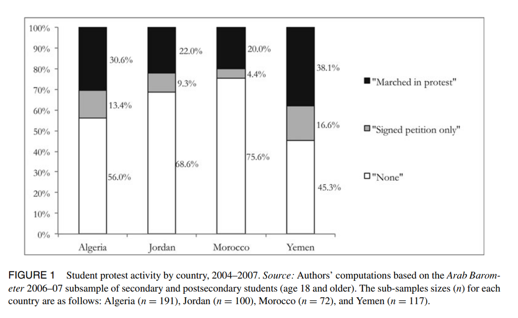

## Background: Tunisia

- Gains independence from France in 1956, led by Habib Bourguiba for the next three decades
- Zine El Abidine Ben Ali takes power in a bloodless coup in 1987
- Ben Ali briefly loosens restrictions on the press, but ultimately formalizes what were previously informal methods of repression

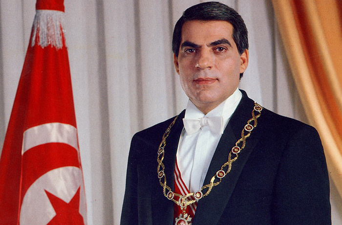

## Background: Tunisia

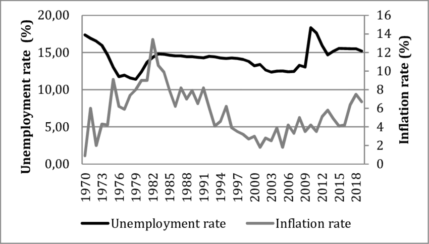

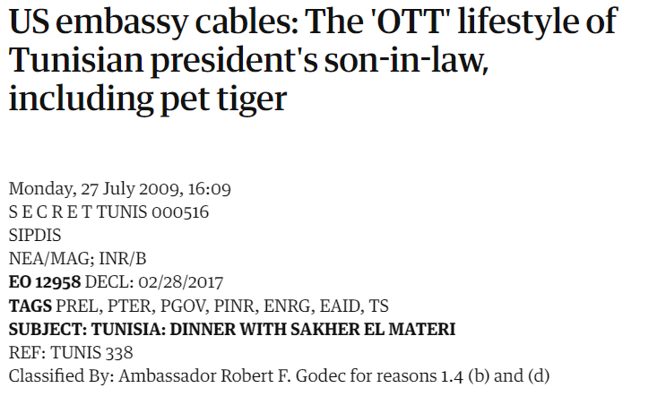

## Background: Tunisia

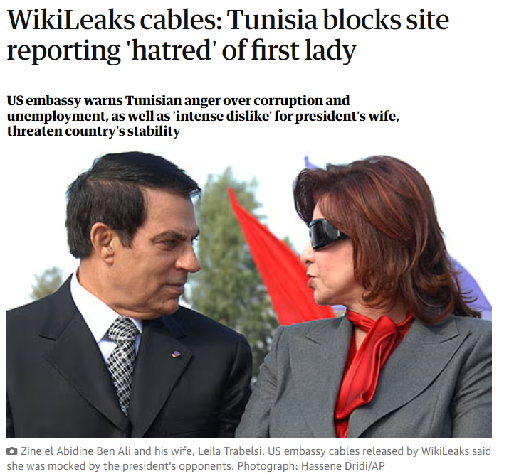

- Characterized as a “police state” with poor economic growth, fractured civil society, and worsening corruption
  - Tunisia probably more appropriate categorized as a weak hybrid state.
- Further exacerbated by what was seen as the opulent lifestyle of Ben Ali and his family

## Arab Spring in Tunisia

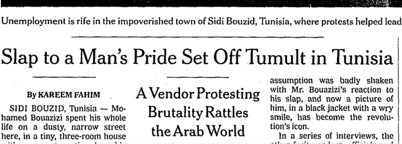

## Arab Spring in Tunisia

- Police reported to kill hundreds during escalating riots
- January 13, 2011: Ben Ali promises not to run for office, but also imposes a state of emergency
- January 14, 2011: Ben Ali flees to Saudi Arabia, Rachid Ghannouchi forms an interim government
- May - June 2011: Ghannouchi resigns amid continued protests. Ben Ali convicted in absentia
- October 2011: Tunisia holds parliamentary elections

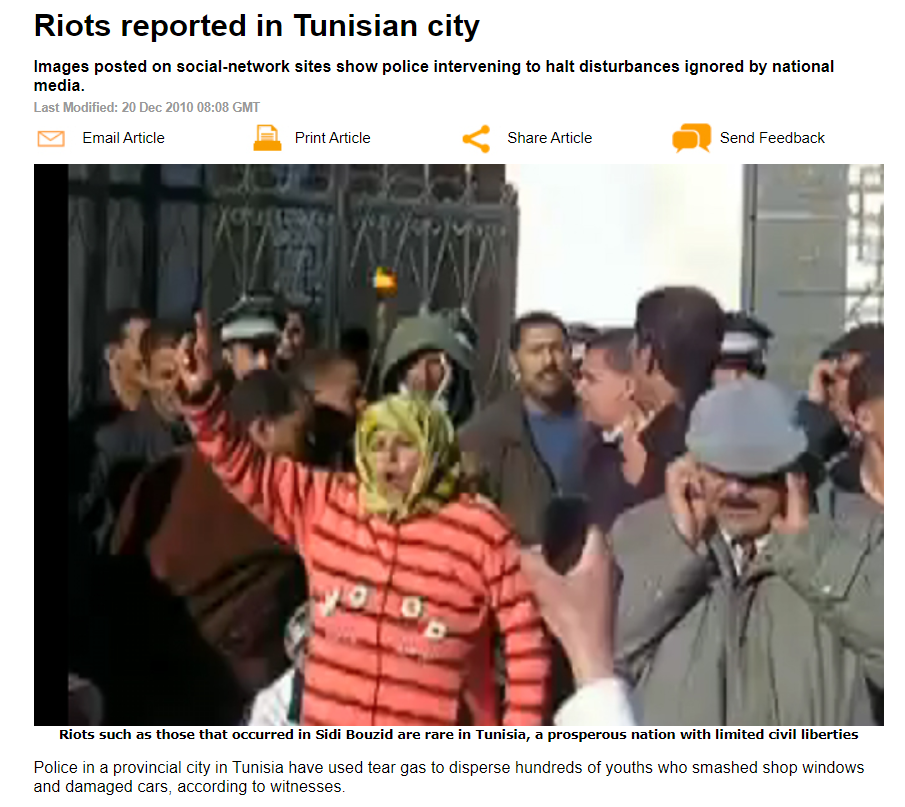

## Arab Spring: Diffusion

- January 14, 2011: initial unrest in Libya and Jordan
- January 17, 2011: initial unrest in Egypt
- January 24, 2011: protests in Yemen
- February 14, 2011: protests in Bahrain

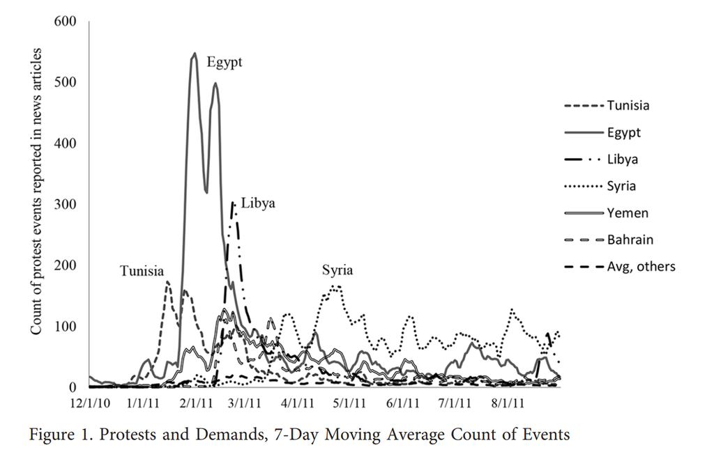

## Arab Spring: Trajectories

- **Egypt:** Mubarak resigns after losing military (and U.S.) support.
- **Libya:** Qaddafi attempts to retain power. Qaddafi overthrown in a violent coup followed by two civil wars.
- **Yemen:** Saleh steps down in exchange for immunity. Later factional fighting ultimately leads to civil war that is ongoing today.
- **Syria:** Assad initially flees, but ultimately holds on through subsequent civil war.
- **Bahrain:** King Hamad declares a three month state of emergency. Holds on to power

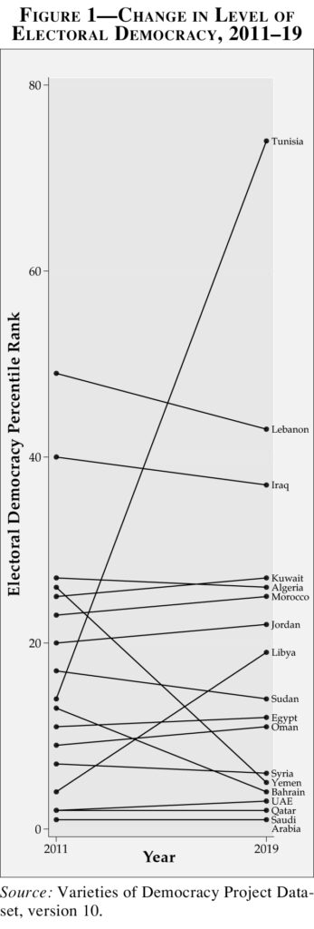

## Arab Spring: Outcomes for Tunisia

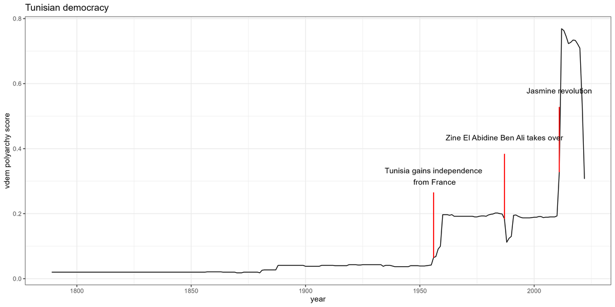

### The cycle

1. **Heightened conflict**: sudden emergence of protest in a repressive state
2. **Geographic and sectoral diffusion**: expansion to Libya and Syria. Involvement of western powers.
3. **New actors**: labor/civil society organizations, “political Islam” organizations and parties
4. **Expansion of the repertoire**: regime change, occupy-style protests, civil war (Syria and Libya)
5. **New claims**: political Islam, in particular, emerged as an important cleavage in multiple states

# Issues

- Why does protest spread in waves? Why did the Arab Spring revolts spread so rapidly - including to countries where they were unlikely to succeed?
- Why do protests appear to emerge “out of nowhere” and then topple regimes?

## Spurious Correlations

Maybe seemingly correlated events are actually just independent reactions to the same events:

- Post WWII anti-imperialist conflicts coincided with weakness of European empires
- The post-Soviet wave coincided with the collapse of the USSR
- Arab Spring happens amid a global recession and regional backlash against the war on terror
- The Arab spring revolts also mostly emerge in personalist dictatorships that are already vulnerable to collapse.

## Thresholds and cascades

Assume that:

- Everyone has a minimal level of safety that they want to have before they’ll join a protest. A “threshold to revolt”
- Every additional participant in a protest makes the event safer. The expectation that others are unhappy can be enough to tip a huge segment of the population to participate.

. . .

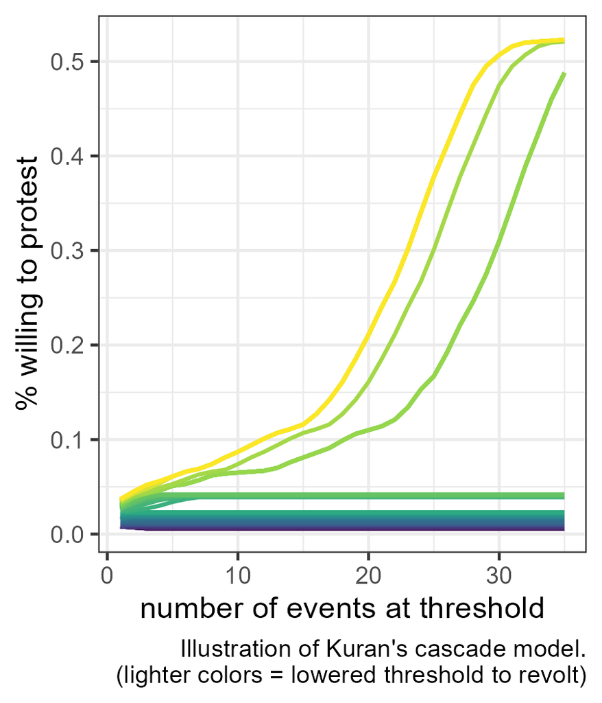

### Thresholds and cascades

Thresholds and cascades might help explain why events like the Arab Spring revolts always seem “surprising”:

- Widespread discontent but no legal outlet for voicing it (corrupt states with limited media freedom)
- An external shock reveals that public support is weaker than it looks
- Protest eventually reaches a tipping point where the potential benefits exceed costs for most potential protesters.

## Cognitive shortcuts

- Cost-benefit calculations are cognitively hard, so people take mental shortcuts
- The choice to emulate Tunisian protests in Saudi Arabia was based on a view among protesters that both cases were “similar enough” to have similar outcomes. (“representativeness” heuristic)
- Protest spreads even to locations where regimes are strong and the chances of success are extremely low.

## International Support and Coordination

- Regional waves like the Arab Spring may be better understood as the result of changes in a shared *international* opportunity structure
- 6,000+ International NGOs founded since the end of WWII along with some emergent norms in favor of universal human rights.
- Transnational Advocacy Networks link countries and the International POS

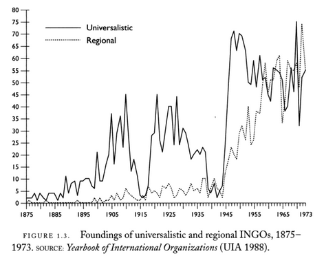

Keck, Margaret E., and Kathryn A. Sikkink. Activists beyond borders: Advocacy networks in international politics. Cornell University Press, 2014.